# Gee whiz, R!

Author

Brian O’Meara

This is showing what can be done with R in [quarto](https://quarto.org). This page is at this [link](https://bomeara.github.io/geewhizR/) but see the source [here](https://github.com/bomeara/geewhizR/blob/main/index.qmd). Look at the functions.R file for the underlying functions, and run.R for doing this with base R. I also include bad.R to provide an example of what not to do. A slightly more advanced version of the good way would convert `run.R` into a set of targets for use with the `targets` package (Landau 2021), which lets you do more complex workflows. To run the R version, you can do `Rscript run.R` from the command line or `source('run.R')` in R; to do quarto, you can do `quarto render index.qmd` from the command line or use the “Render” button in RStudio.

**Datasaurus**

First, we are going to use the `datasauRus` package (Davies, Locke, and D’Agostino McGowan 2022) to show the “Datasaurus Dozen” dataset. We can first investigate it with some basic summary stats with `dplyr` (Wickham et al. 2023) and a plot using `ggplot2` (Wickham 2016).

Showing summary information for the `datasaurus_dozen` dataset, using `knitr` (Xie 2023) to make it look nice:

| dataset | count | mean_x | mean_y | sd_x | sd_y | correlation |
| --- | --- | --- | --- | --- | --- | --- |
| away | 142 | 54.26610 | 47.83472 | 16.76983 | 26.93974 | -0.0641284 |
| bullseye | 142 | 54.26873 | 47.83082 | 16.76924 | 26.93573 | -0.0685864 |
| circle | 142 | 54.26732 | 47.83772 | 16.76001 | 26.93004 | -0.0683434 |
| dino | 142 | 54.26327 | 47.83225 | 16.76514 | 26.93540 | -0.0644719 |
| dots | 142 | 54.26030 | 47.83983 | 16.76774 | 26.93019 | -0.0603414 |
| h_lines | 142 | 54.26144 | 47.83025 | 16.76590 | 26.93988 | -0.0617148 |
| high_lines | 142 | 54.26881 | 47.83545 | 16.76670 | 26.94000 | -0.0685042 |
| slant_down | 142 | 54.26785 | 47.83590 | 16.76676 | 26.93610 | -0.0689797 |
| slant_up | 142 | 54.26588 | 47.83150 | 16.76885 | 26.93861 | -0.0686092 |
| star | 142 | 54.26734 | 47.83955 | 16.76896 | 26.93027 | -0.0629611 |
| v_lines | 142 | 54.26993 | 47.83699 | 16.76996 | 26.93768 | -0.0694456 |
| wide_lines | 142 | 54.26692 | 47.83160 | 16.77000 | 26.93790 | -0.0665752 |
| x_shape | 142 | 54.26015 | 47.83972 | 16.76996 | 26.93000 | -0.0655833 |

Plot of data all together:

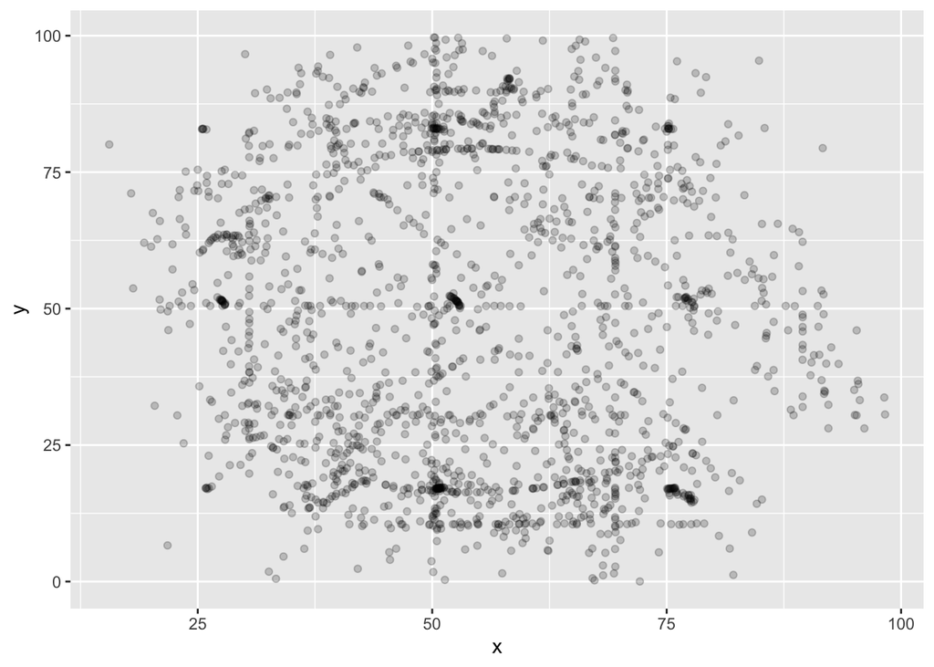

```r
ggplot(datasaurus_dozen, aes(x=x, y=y)) + geom_point(alpha=0.2)
```

**Basic plot**

Looks all the same, right? Maybe if we plot the data by dataset, using `facet_wrap` in `ggplot2`

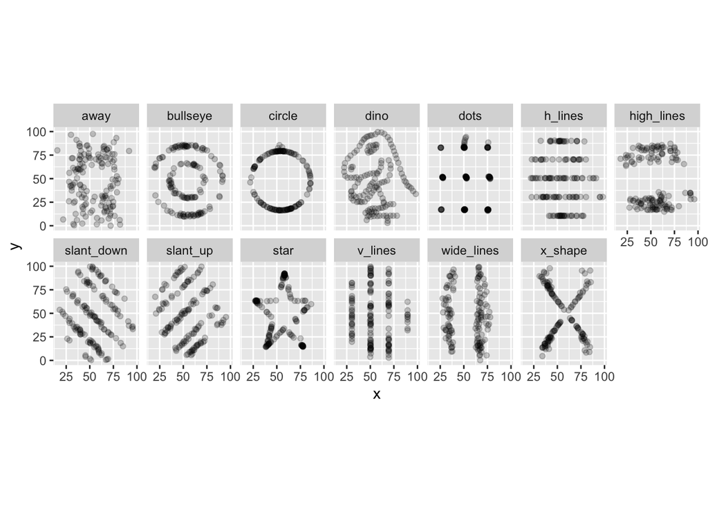

Moral of the story: LOOK AT YOUR DATA. This finds all sorts of problems: having -99 instead of NA for missing data, having a single outlier that was measured in millimeters not meters, and so on.

**Map**

We pull information from the Global Biodiversity Information Facility (GBIF) to get the locations of salamanders using `rgbif` (Chamberlain et al. 2024), then `leaflet` (Cheng, Karambelkar, and Xie 2023) to plot them. For simplicity, we only have special colors for the seven most commonly recorded species, but you can click on the “Other” points to see what they are, too.

[interactive chart not shown]

**Phylogeny**

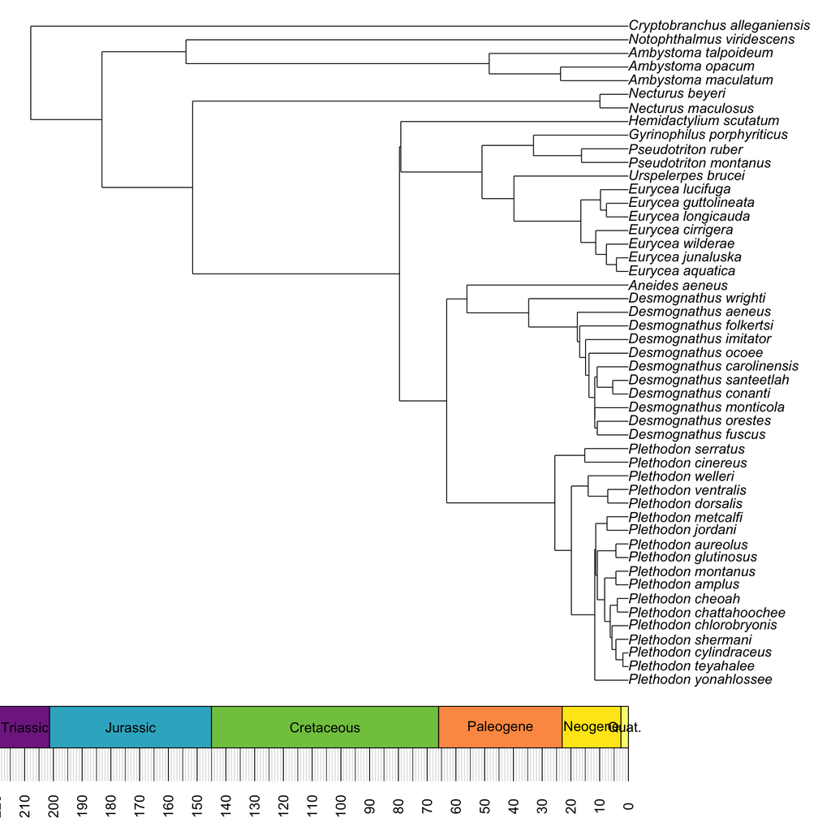

```r
salamander_tree <- get_datelife_tree(summarize_salamanders(salamander_data))
strap::geoscalePhylo(salamander_tree, units="Period", cex.tip=1, cex.age=1, cex.ts=1)
```

**Images**

[iNaturalist](https://www.inaturalist.org) stores lots of information from community scientists, including photos (and this information later flows into GBIF). We can include these photos. Here, we use research grade images of the Eastern Newt, *Notophthalmus viridescens*, using `rinat` (Barve and Hart 2022).

Here’s one image. It’s from the United States on 2024-02-10 by Jorge Aguilera.

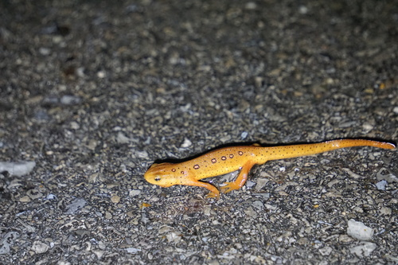

Here’s another image. It’s from the Polk County, TN, USA on 2024-02-06 by Jared Gorrell.

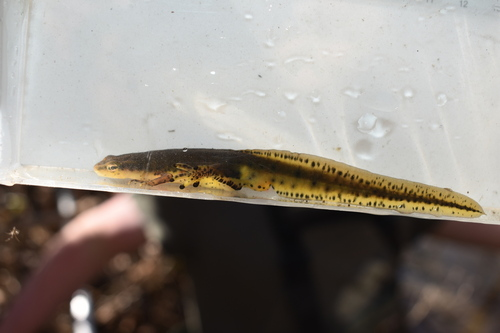

And a third image. It’s from the Tennessee, US on 2024-02-03 by jaron sedlock.

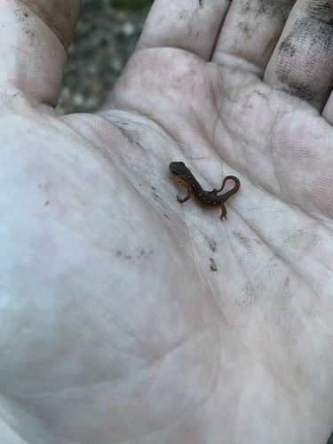

Fourth image. It’s from the Tennessee, US on 2024-02-03 by jaron sedlock.

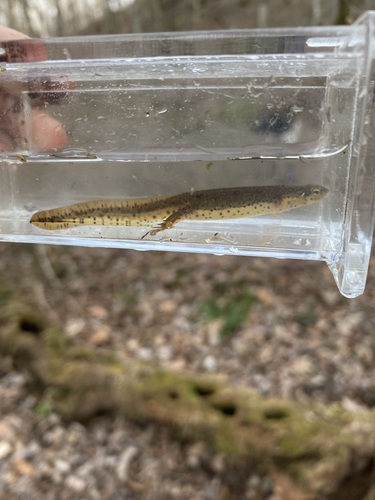

## Citations

Barve, Vijay, and Edmund Hart. 2022. “Rinat: Access ’iNaturalist’ Data Through APIs.” https://CRAN.R-project.org/package=rinat.

Chamberlain, Scott, Vijay Barve, Dan Mcglinn, Damiano Oldoni, Peter Desmet, Laurens Geffert, and Karthik Ram. 2024. “Rgbif: Interface to the Global Biodiversity Information Facility API.” https://CRAN.R-project.org/package=rgbif.

Cheng, Joe, Bhaskar Karambelkar, and Yihui Xie. 2023. “Leaflet: Create Interactive Web Maps with the JavaScript ’Leaflet’ Library.” https://CRAN.R-project.org/package=leaflet.

Davies, Rhian, Steph Locke, and Lucy D’Agostino McGowan. 2022. “datasauRus: Datasets from the Datasaurus Dozen.” https://CRAN.R-project.org/package=datasauRus.

Landau, William. 2021. “The Targets r Package: A Dynamic Make-Like Function-Oriented Pipeline Toolkit for Reproducibility and High-Performance Computing.” *Journal of Open Source Software* 6 (57): 2959. https://doi.org/10.21105/joss.02959.

McTavish, Emily Jane, Cody E. Hinchliff, James F. Allman, Joseph W. Brown, Karen A. Cranston, Mark T. Holder, Jonathan A. Rees, and Stephen A. Smith. 2015. “Phylesystem: A Git-Based Data Store for Community-Curated Phylogenetic Estimates.” *Bioinformatics* 31 (17): 2794–2800. https://doi.org/10.1093/bioinformatics/btv276.

O’Meara, Brian, Luna L. Sanchez-Reyes, Jonathan Eastman, Tracy Heath, April Wright, Klaus Schliep, Scott Chamberlain, et al. 2024. “Datelife: Scientific Data on Time of Lineage Divergence for Your Taxa.” https://doi.org/10.5281/zenodo.593938.

Wickham, Hadley. 2016. “Ggplot2: Elegant Graphics for Data Analysis.” https://ggplot2.tidyverse.org.

Wickham, Hadley, Romain François, Lionel Henry, Kirill Müller, and Davis Vaughan. 2023. “Dplyr: A Grammar of Data Manipulation.” https://CRAN.R-project.org/package=dplyr.

Xie, Yihui. 2023. “Knitr: A General-Purpose Package for Dynamic Report Generation in r.” https://yihui.org/knitr/.